# NBA Award Prediction using Machine Learning

This is my project that uses machine learning to predict the winners of each of the five major individual NBA awards (Most Valuable Player, Defensive Player of the Year, Rookie of the Year, Most Improved Player, and Sixth Man of the Year). On this website, you will find the notebooks that I created in order to scrape my data, clean and process it, and create my models.

You can find the source code and data for this project on Github at:

https://github.com/tomerzur/NBA-Award-Prediction

If you want to read the final report for the project, you can find it at:

https://github.com/tomerzur/NBA-Award-Prediction/blob/main/Final%20Report.pdf

[figure not shown]

Image Source: https://hoopshype.com/wp-content/uploads/sites/92/2019/10/gettyimages-168122500.jpg?w=1000&h=600&crop=1

Back to Table of Contents

# Scraping the Data

```python
import numpy as np
import pandas as pd
import urllib.request as urllib
from bs4 import BeautifulSoup, Comment
from selenium import webdriver
from datetime import datetime
import time
import random
import os
import string
```

In order to create my award models, the first step is to run this notebook that scrapes all of the data that we will use. We are scraping the data from basketball-reference.com, and will be scraping by using a gecko driver that will automatically open a firefox window. The driver will visit basketball-reference.com, and visit each player profile on the website to get all of the player season data. It will also visit each award voting page on the site to get all of the award data. In total, this script will run for a few hours before it has scraped all of the data.

First, set the path of your gecko driver. I put my gecko driver file in the same directory as this project.

```python
PATH=os.path.abspath(os.getcwd()) + '/geckodriver'
```

I will create two dataframes that will be used to store all of the data that I am scraping.

```python
# get totals
player_seasons = pd.DataFrame(columns=['player', 'season', 'age', 'team', 'position', 'g', 'gs', 'mp', 'fg', 'fga', 'fg_pct',
                                       'three_p', 'three_pa', 'three_pct', 'two_p', 'two_pa', 'two_pct', 'efg', 'ft',
                                       'fta', 'ft_pct', 'orb', 'drb', 'trb', 'ast', 'stl', 'blk', 'tov','pf', 'pts', 'trp_dbl'])
player_seasons.set_index(['player', 'season'], inplace = True)

award_data = pd.DataFrame(columns=['player', 'season', 'award', 'first_place_votes', 'award_pts_won', 'award_pts_max'])
award_data.set_index(['player', 'season'], inplace = True)
```

## Scraping Award Data

This is the code that scrapes the award data for each year. After filling in the award_data dataframe, we save this dataframe to a csv.

```python
# get url of award voting results for a given year
def get_award_url(year):
    return f"https://www.basketball-reference.com/awards/awards_{year}.html"

# extract award data from beautiful soup object and add it to award_rows_list
def scrape_award_data(award_name, soup):
    #get rows of award votes from table
    awardTable = soup.find("table", {"id": award_name})
    if awardTable is None:
        awardTable = soup.find("table", {"id": f"nba_{award_name}"})
    if awardTable is not None:
        awardRows = awardTable.find("tbody").find_all("tr")
        print(f"Got rows of {award_name} players from table, starting to iterate through rows")

        #iterate through votes on page, filling data into award_data dataframe
        for row in awardRows:
            if row.get('class') == None:
                player_name = row.find("td", {"data-stat":"player"}).find("a").get_text()
                first_place_votes = row.find("td", {"data-stat":"votes_first"}).get_text()
                award_pts_won = row.find("td", {"data-stat":"points_won"}).get_text()
                award_pts_max = row.find("td", {"data-stat":"points_max"}).get_text()
                award_rows_list.append({'player': player_name, 'season': year, 'award': award_name,
                                                'first_place_votes': first_place_votes, 'award_pts_won': award_pts_won,
                                                'award_pts_max': award_pts_max})


browser = webdriver.Firefox(executable_path = PATH)

award_rows_list = []
# award voting data is available on bbref from 1956
years = range(1956, datetime.now().year)

for year in years:
    sada = browser.get(get_award_url(year))
    time.sleep(3)
    source = browser.page_source
    soup = BeautifulSoup(source, 'html.parser')
    print(f"Year: {year}")

    scrape_award_data('mvp', soup)
    scrape_award_data('roy', soup)
    scrape_award_data('dpoy', soup)
    scrape_award_data('smoy', soup)
    scrape_award_data('mip', soup)

    time.sleep(random.randint(0,1))

browser.close()
award_data = pd.DataFrame(award_rows_list, columns=['player', 'season', 'award', 'first_place_votes', 'award_pts_won', 'award_pts_max'])
award_data.set_index(['player', 'season'], inplace = True)
```

```
Year: 1956
Got rows of mvp players from table, starting to iterate through rows
Year: 1957
Got rows of mvp players from table, starting to iterate through rows
Year: 1958
Got rows of mvp players from table, starting to iterate through rows
Year: 1959
Got rows of mvp players from table, starting to iterate through rows
Got rows of roy players from table, starting to iterate through rows
Year: 1960
Got rows of mvp players from table, starting to iterate through rows
Year: 1961
Got rows of mvp players from table, starting to iterate through rows
Year: 1962
Got rows of mvp players from table, starting to iterate through rows
Year: 1963
Got rows of mvp players from table, starting to iterate through rows
Year: 1964
Got rows of mvp players from table, starting to iterate through rows
Got rows of roy players from table, starting to iterate through rows
Year: 1965
Got rows of mvp players from table, starting to iterate through rows
Got rows of roy players from table, starting to iterate through rows
Year: 1966
Got rows of mvp players from table, starting to iterate through rows
Got rows of roy players from table, starting to iterate through rows
Year: 1967
Got rows of mvp players from table, starting to iterate through rows
Got rows of roy players from table, starting to iterate through rows
Year: 1968
Got rows of mvp players from table, starting to iterate through rows
Got rows of roy players from table, starting to iterate through rows
Year: 1969
Got rows of mvp players from table, starting to iterate through rows
Got rows of roy players from table, starting to iterate through rows
Year: 1970
Got rows of mvp players from table, starting to iterate through rows
Got rows of roy players from table, starting to iterate through rows
Year: 1971
Got rows of mvp players from table, starting to iterate through rows
```

[output cut: 242 more lines]

```
Got rows of dpoy players from table, starting to iterate through rows
Got rows of smoy players from table, starting to iterate through rows
Got rows of mip players from table, starting to iterate through rows
Year: 2019
Got rows of mvp players from table, starting to iterate through rows
Got rows of roy players from table, starting to iterate through rows
Got rows of dpoy players from table, starting to iterate through rows
Got rows of smoy players from table, starting to iterate through rows
Got rows of mip players from table, starting to iterate through rows
Year: 2020
Got rows of mvp players from table, starting to iterate through rows
Got rows of roy players from table, starting to iterate through rows
Got rows of dpoy players from table, starting to iterate through rows
Got rows of smoy players from table, starting to iterate through rows
Got rows of mip players from table, starting to iterate through rows
```

```python
award_data.to_csv('data/award_data.csv')
```

## Scraping Player Data

This is the code that scrapes each player's statistics that they recorded each season. It loops through the player directory on basketball-reference.com, and scrapes data from each player's profile on the website. After filling in the player_seasons dataframe, we save this dataframe to a csv. WARNING: This takes a few hours to run, as there are thousands of players that we are scraping data for, and we are waiting 0-1 seconds before visiting each player's profile page (in order to avoid overwhelming basketball-reference.com).

```python
# scrape all of the player basic stats data for each season

# get url of all players whose last name starts with the given letter
def get_letter_url(letter):
    return f"https://www.basketball-reference.com/players/{letter}/"


browser = webdriver.Firefox(executable_path = PATH)
player_season_list = []

for letter in string.ascii_lowercase[::-1]:
    print(f"Letter: {letter}")
    time.sleep(random.randint(0,1))
    html = urllib.urlopen(get_letter_url(letter))
    soup = BeautifulSoup(html.read())
    html.close()

    #get rows of players from table
    playerTable = soup.find("table", {"id":"players"})
    playerRows = playerTable.find("tbody").find_all("tr")

    #iterate through players on page, filling data into players dataframe
    for row in playerRows:
        if row.get('class') == None:
            player_name = player_link = row.find("th", {"data-stat":"player"}).find("a").get_text()
            player_link = row.find("th", {"data-stat":"player"}).find("a")['href']
            full_player_link = f"https://www.basketball-reference.com{player_link}"
            print(player_name)

            time.sleep(random.randint(0,1))
            sada = browser.get(full_player_link)
            source = browser.page_source
            player_soup = BeautifulSoup(source, 'html.parser')

            totalsTable = player_soup.find("table", {"id":"totals"})
            totalsRows = totalsTable.find("tbody").find_all("tr")
            time.sleep(random.randint(0,1))

            prev_yr = 0
            for row_t in totalsRows:
                league_soup = row_t.find("td", {"data-stat":"lg_id"})
                if league_soup is not None and league_soup.find("a") is not None:
                    league = league_soup.find("a").get_text()
                else:
                    league = 'N/A'
                if league == "NBA":
                    season_str = row_t.find("th", {"data-stat":"season"}).find("a").get_text()[0:4]
                    year = int(season_str) + 1
                    if year == prev_yr:
                        team = row_t.find("td", {"data-stat":"team_id"}).find("a").get_text() + " "
                        update_team = player_season_list[-1]
                        update_team['team'] = update_team['team'] + team
                        player_season_list[-1] = update_team
                    else:
                        team_soup = row_t.find("td", {"data-stat":"team_id"})
                        if team_soup.find("a") is not None:
                            team = row_t.find("td", {"data-stat":"team_id"}).find("a").get_text() + " "
                        else:
                            team = ""

                        age = row_t.find("td", {"data-stat":"age"}).get_text()
                        position = row_t.find("td", {"data-stat":"pos"}).get_text()
                        g = row_t.find("td", {"data-stat":"g"}).get_text()
                        gs = row_t.find("td", {"data-stat":"gs"}).get_text()
                        mp = row_t.find("td", {"data-stat":"mp"}).get_text()
                        fg = row_t.find("td", {"data-stat":"fg"}).get_text()
                        fga = row_t.find("td", {"data-stat":"fga"}).get_text()
                        fg_pct = row_t.find("td", {"data-stat":"fg_pct"}).get_text()
                        if row_t.find("td", {"data-stat":"fg3"}) is not None:
                            three_p = row_t.find("td", {"data-stat":"fg3"}).get_text()
                        else:
                            three_p = 0
                        if row_t.find("td", {"data-stat":"fg3a"}) is not None:
                            three_pa = row_t.find("td", {"data-stat":"fg3a"}).get_text()
                        else:
                            three_pa = 0
                        if row_t.find("td", {"data-stat":"fg3_pct"}) is not None:
                            three_pct = row_t.find("td", {"data-stat":"fg3_pct"}).get_text()
                        else:
                            three_pct = 0
                        if row_t.find("td", {"data-stat":"fg2"}) is not None:
                            two_p = row_t.find("td", {"data-stat":"fg2"}).get_text()
                        else:
                            two_p = fg
                        if row_t.find("td", {"data-stat":"fg2a"}) is not None:
                            two_pa = row_t.find("td", {"data-stat":"fg2a"}).get_text()
                        else:
                            two_pa = fga
                        if row_t.find("td", {"data-stat":"fg2_pct"}) is not None:
                            two_pct = row_t.find("td", {"data-stat":"fg2_pct"}).get_text()
                        else:
                            two_pct = fg_pct
                        if row_t.find("td", {"data-stat":"efg_pct"}) is not None:
                            efg = row_t.find("td", {"data-stat":"efg_pct"}).get_text()
                        else:
                            efg = fg_pct
                        ft = row_t.find("td", {"data-stat":"ft"}).get_text()
                        fta = row_t.find("td", {"data-stat":"fta"}).get_text()
                        ft_pct = row_t.find("td", {"data-stat":"ft_pct"}).get_text()
                        if row_t.find("td", {"data-stat":"orb"}) is not None:
                            orb = row_t.find("td", {"data-stat":"orb"}).get_text()
                        else:
                            orb = ''
                        if row_t.find("td", {"data-stat":"drb"}) is not None:
                            drb = row_t.find("td", {"data-stat":"drb"}).get_text()
                        else:
                            drb = ''
                        trb = row_t.find("td", {"data-stat":"trb"}).get_text()
                        ast = row_t.find("td", {"data-stat":"ast"}).get_text()
                        if row_t.find("td", {"data-stat":"stl"}) is not None:
                            stl = row_t.find("td", {"data-stat":"stl"}).get_text()
                        else:
                            stl = ''
                        if row_t.find("td", {"data-stat":"blk"}) is not None:
                            blk = row_t.find("td", {"data-stat":"blk"}).get_text()
                        else:
                            blk = ''
                        if row_t.find("td", {"data-stat":"tov"}) is not None:
                            tov = row_t.find("td", {"data-stat":"tov"}).get_text()
                        else:
                            tov = ''
                        pf = row_t.find("td", {"data-stat":"pf"}).get_text()
                        pts = row_t.find("td", {"data-stat":"pts"}).get_text()
                        trp_dbl_soup = row_t.find("td", {"data-stat":"trp_dbl"})
                        if trp_dbl_soup is None:
                            trp_dbl = ''
                        else:
                            trp_dbl = trp_dbl_soup.get_text()

                        player_season_list.append({'player': player_name, 'season': year, 'age': age, 'team': team.strip(),
                                                   'position': position, 'g': g, 'gs': gs, 'mp': mp, 'fg': fg, 'fga': fga,
                                                   'fg_pct': fg_pct, 'three_p': three_p, 'three_pa': three_pa,
                                                   'three_pct': three_pct, 'two_p': two_p, 'two_pa': two_pa, 'two_pct': two_pct,
                                                   'efg': efg, 'ft': ft, 'fta': fta, 'ft_pct': ft_pct, 'orb': orb, 'drb': drb,
                                                   'trb': trb, 'ast': ast, 'stl': stl, 'blk': blk, 'tov': tov,'pf': pf,
                                                   'pts': pts, 'trp_dbl': trp_dbl})
                    prev_yr = year


browser.close()

player_seasons = pd.DataFrame(player_season_list, columns=['player', 'season', 'age', 'team', 'position', 'g', 'gs', 'mp', 'fg', 'fga', 'fg_pct',
                                       'three_p', 'three_pa', 'three_pct', 'two_p', 'two_pa', 'two_pct', 'efg', 'ft',
                                       'fta', 'ft_pct', 'orb', 'drb', 'trb', 'ast', 'stl', 'blk', 'tov','pf', 'pts', 'trp_dbl'])
player_seasons.set_index(['player', 'season'], inplace = True)
```

```python
player_seasons
```

```python
player_seasons.to_csv('data/player_seasons.csv')
```

Back to Table of Contents

# Exploratory Data Analysis

```python
import pandas as pd
import matplotlib.pyplot as plt
```

In this notebook, we do some exploratory data analysis. We look at the distribution of award points among players, and how that has changed in recent years compared to early years. We also look at how correlated each feature is to our target variable (award points).  
This notebook is intended to be run right after scraping the data ('scrape_data' notebook).

```python
# mvp
mvp_data = pd.read_csv('data/mvp_data.csv')
mvp_data_1956 = mvp_data[mvp_data['season'] == 1956]
mvp_data_2020 = mvp_data[mvp_data['season'] == 2020]

# dpoy
dpoy_data = pd.read_csv('data/dpoy_data.csv')
dpoy_data_1983 = dpoy_data[dpoy_data['season'] == 1983]
dpoy_data_2020 = dpoy_data[dpoy_data['season'] == 2020]

# roy
roy_data = pd.read_csv('data/roy_data.csv')
roy_data_1966 = roy_data[roy_data['season'] == 1966]
roy_data_2020 = roy_data[roy_data['season'] == 2020]

# mip
mip_data = pd.read_csv('data/mip_data.csv')
mip_data_1986 = mip_data[mip_data['season'] == 1986]
mip_data_2020 = mip_data[mip_data['season'] == 2020]

# smoy
smoy_data = pd.read_csv('data/mvp_data.csv')
smoy_data_1983 = mvp_data[mvp_data['season'] == 1983]
smoy_data_2020 = mvp_data[mvp_data['season'] == 2020]
```

## Distributions of award points among players

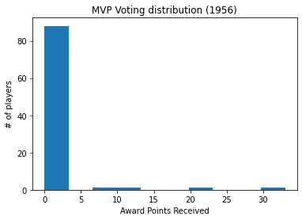

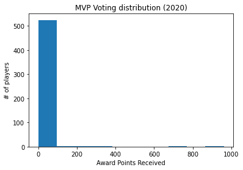

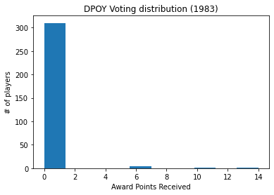

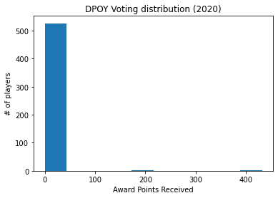

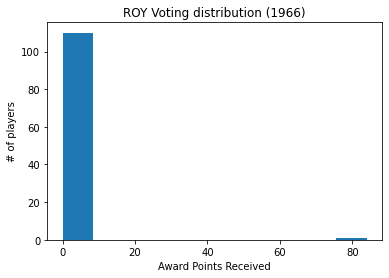

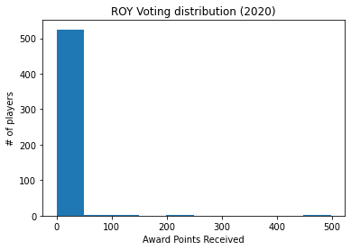

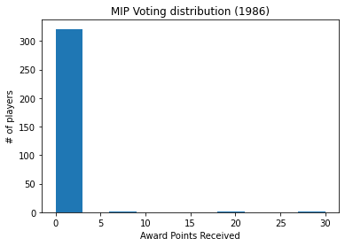

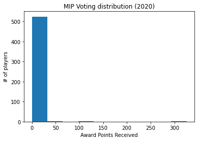

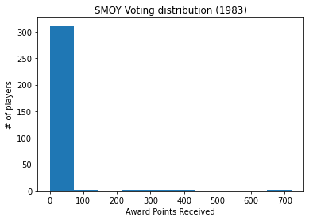

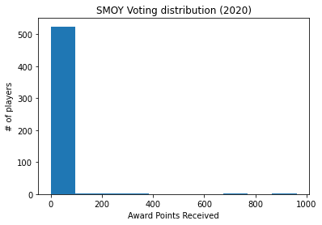

```python
plt.hist(mvp_data_1956['award_pts_won'], bins=10)
plt.ylabel('# of players')
plt.xlabel('Award Points Received')
plt.title("MVP Voting distribution (1956)")
plt.show()

plt.hist(mvp_data_2020['award_pts_won'], bins=10)
plt.ylabel('# of players')
plt.xlabel('Award Points Received')
plt.title("MVP Voting distribution (2020)")
plt.show()

plt.hist(dpoy_data_1983['award_pts_won'], bins=10)
plt.ylabel('# of players')
plt.xlabel('Award Points Received')
plt.title("DPOY Voting distribution (1983)")
plt.show()

plt.hist(dpoy_data_2020['award_pts_won'], bins=10)
plt.ylabel('# of players')
plt.xlabel('Award Points Received')
plt.title("DPOY Voting distribution (2020)")
plt.show()

plt.hist(roy_data_1966['award_pts_won'], bins=10)
plt.ylabel('# of players')
plt.xlabel('Award Points Received')
plt.title("ROY Voting distribution (1966)")
plt.show()

plt.hist(roy_data_2020['award_pts_won'], bins=10)
plt.ylabel('# of players')
plt.xlabel('Award Points Received')
plt.title("ROY Voting distribution (2020)")
plt.show()

plt.hist(mip_data_1986['award_pts_won'], bins=10)
plt.ylabel('# of players')
plt.xlabel('Award Points Received')
plt.title("MIP Voting distribution (1986)")
plt.show()

plt.hist(mip_data_2020['award_pts_won'], bins=10)
plt.ylabel('# of players')
plt.xlabel('Award Points Received')
plt.title("MIP Voting distribution (2020)")
plt.show()

plt.hist(smoy_data_1983['award_pts_won'], bins=10)
plt.ylabel('# of players')
plt.xlabel('Award Points Received')
plt.title("SMOY Voting distribution (1983)")
plt.show()

plt.hist(smoy_data_2020['award_pts_won'], bins=10)
plt.ylabel('# of players')
plt.xlabel('Award Points Received')
plt.title("SMOY Voting distribution (2020)")
plt.show()
```

## Correlation between each feature and the number of award points won

### MVP

```python
mvp_data.corr()['award_pts_won']
```

```
Unnamed: 0           0.019247
season               0.002749
age                  0.020178
g                    0.086676
gs                   0.169350
mp                   0.173564
fg                   0.267111
fga                  0.244054
fg_pct               0.071227
three_p              0.114388
three_pa             0.116982
three_pct            0.019931
two_p                0.256113
two_pa               0.230353
two_pct              0.069625
efg                  0.066746
ft                   0.304983
fta                  0.307409
ft_pct               0.038090
orb                  0.128628
drb                  0.223288
trb                  0.206886
ast                  0.213928
stl                  0.184815
blk                  0.172898
tov                  0.227186
pf                   0.090094
pts                  0.282150
trp_dbl              0.274015
first_place_votes    0.762333
award_pts_won        1.000000
award_pts_max        0.024172
Name: award_pts_won, dtype: float64
```

### Defensive Player of the Year

```python
dpoy_data.corr()['award_pts_won']
```

```
Unnamed: 0           0.011335
season               0.038860
age                  0.006051
g                    0.058056
gs                   0.111431
mp                   0.098778
fg                   0.089285
fga                  0.075712
fg_pct               0.054293
three_p              0.018555
three_pa             0.020388
three_pct           -0.020168
two_p                0.092770
two_pa               0.079960
two_pct              0.048388
efg                  0.046254
ft                   0.103890
fta                  0.127202
ft_pct              -0.021682
orb                  0.128232
drb                  0.177603
trb                  0.167210
ast                  0.053317
stl                  0.102887
blk                  0.205363
tov                  0.085688
pf                   0.075432
pts                  0.091997
trp_dbl              0.066889
first_place_votes    0.828236
award_pts_won        1.000000
award_pts_max        0.056521
Name: award_pts_won, dtype: float64
```

### Rookie of the Year

```python
roy_data.corr()['award_pts_won']
```

```
Unnamed: 0          -0.003692
season               0.034789
age                 -0.078611
g                    0.043330
gs                   0.074855
mp                   0.067852
fg                   0.070875
fga                  0.074720
fg_pct               0.010842
three_p              0.044714
three_pa             0.050558
three_pct            0.015627
two_p                0.064556
two_pa               0.066084
two_pct              0.011416
efg                  0.012403
ft                   0.070829
fta                  0.072894
ft_pct               0.016343
orb                  0.045228
drb                  0.063805
trb                  0.056960
ast                  0.062237
stl                  0.056279
blk                  0.039203
tov                  0.089210
pf                   0.047087
pts                  0.073712
trp_dbl              0.031105
first_place_votes    0.741657
award_pts_won        1.000000
award_pts_max        0.050702
Name: award_pts_won, dtype: float64
```

### Most Improved Player

```python
mip_data.corr()['award_pts_won']
```

```
Unnamed: 0           0.010919
season               0.041060
age                 -0.057126
g                    0.070200
gs                   0.117863
mp                   0.113685
fg                   0.129356
fga                  0.124338
fg_pct               0.038491
three_p              0.092617
three_pa             0.090196
three_pct            0.018871
two_p                0.117753
two_pa               0.112425
two_pct              0.036240
efg                  0.041010
ft                   0.126453
fta                  0.123841
ft_pct               0.029229
orb                  0.080966
drb                  0.112896
trb                  0.106205
ast                  0.093343
stl                  0.100106
blk                  0.067625
tov                  0.119548
pf                   0.086820
pts                  0.133474
trp_dbl              0.036710
first_place_votes    0.849248
award_pts_won        1.000000
award_pts_max        0.061515
Name: award_pts_won, dtype: float64
```

### Sixth Man of the Year

```python
smoy_data.corr()['award_pts_won']
```

```
Unnamed: 0           0.019247
season               0.002749
age                  0.020178
g                    0.086676
gs                   0.169350
mp                   0.173564
fg                   0.267111
fga                  0.244054
fg_pct               0.071227
three_p              0.114388
three_pa             0.116982
three_pct            0.019931
two_p                0.256113
two_pa               0.230353
two_pct              0.069625
efg                  0.066746
ft                   0.304983
fta                  0.307409
ft_pct               0.038090
orb                  0.128628
drb                  0.223288
trb                  0.206886
ast                  0.213928
stl                  0.184815
blk                  0.172898
tov                  0.227186
pf                   0.090094
pts                  0.282150
trp_dbl              0.274015
first_place_votes    0.762333
award_pts_won        1.000000
award_pts_max        0.024172
Name: award_pts_won, dtype: float64
```

Back to Table of Contents

# Get Full Datasets

```python
import numpy as np
import pandas as pd
```

In this notebook I join the award data and player data and then split up the data into individual datasets to be used for each award. I also add a few new features to my dataset (such as % of games started and season number).  
This notebook should be run after you have successfully scraped the data using the 'scrape_data' notebook.

## Load Data

```python
award_data = pd.read_csv('data/award_data.csv')
award_data.head()
```

|  | player | season | award | first_place_votes | award_pts_won | award_pts_max |
| --- | --- | --- | --- | --- | --- | --- |
| 0 | Bob Pettit | 1956 | mvp | 33.0 | 33.0 | 80 |
| 1 | Paul Arizin | 1956 | mvp | 21.0 | 21.0 | 80 |
| 2 | Bob Cousy | 1956 | mvp | 11.0 | 11.0 | 80 |
| 3 | Mel Hutchins | 1956 | mvp | 9.0 | 9.0 | 80 |
| 4 | Dolph Schayes | 1956 | mvp | 2.0 | 2.0 | 80 |

```python
player_season_data = pd.read_csv('data/player_seasons.csv')
player_season_data.tail()
```

|  | player | season | age | team | position | g | gs | mp | fg | fga | ... | orb | drb | trb | ast | stl | blk | tov | pf | pts | trp_dbl |
| --- | --- | --- | --- | --- | --- | --- | --- | --- | --- | --- | --- | --- | --- | --- | --- | --- | --- | --- | --- | --- | --- |
| 22383 | Kelenna Azubuike | 2008 | 24 | GSW | SG | 81 | 17.0 | 1732.0 | 261 | 587 | ... | 107.0 | 217.0 | 324.0 | 75 | 45.0 | 34.0 | 58.0 | 159 | 692 | NaN |
| 22384 | Kelenna Azubuike | 2009 | 25 | GSW | SF | 74 | 51.0 | 2375.0 | 392 | 845 | ... | 112.0 | 258.0 | 370.0 | 117 | 57.0 | 50.0 | 95.0 | 183 | 1063 | NaN |
| 22385 | Kelenna Azubuike | 2010 | 26 | GSW | SF | 9 | 7.0 | 231.0 | 48 | 88 | ... | 12.0 | 29.0 | 41.0 | 10 | 5.0 | 9.0 | 7.0 | 16 | 125 | NaN |
| 22386 | Kelenna Azubuike | 2012 | 28 | DAL | SG | 3 | 0.0 | 18.0 | 3 | 8 | ... | 0.0 | 0.0 | 0.0 | 0 | 1.0 | 0.0 | 4.0 | 1 | 7 | NaN |
| 22387 | Udoka Azubuike | 2021 | 21 | UTA | C | 12 | 0.0 | 49.0 | 4 | 7 | ... | 4.0 | 9.0 | 13.0 | 0 | 1.0 | 4.0 | 3.0 | 8 | 12 | NaN |

5 rows × 31 columns

## Extract new features from data

```python
# add season number as column to data
player_season_data["season_num"] = player_season_data.groupby("player")["season"].rank(method="first", ascending=True)
# add games_started_pct feature
player_season_data["gs_pct"] = player_season_data["gs"] / player_season_data["g"]
```

|  | player | season | age | team | position | g | gs | mp | fg | fga | ... | trb | ast | stl | blk | tov | pf | pts | trp_dbl | season_num | gs_pct |
| --- | --- | --- | --- | --- | --- | --- | --- | --- | --- | --- | --- | --- | --- | --- | --- | --- | --- | --- | --- | --- | --- |
| 22383 | Kelenna Azubuike | 2008 | 24 | GSW | SG | 81 | 17.0 | 1732.0 | 261 | 587 | ... | 324.0 | 75 | 45.0 | 34.0 | 58.0 | 159 | 692 | NaN | 2.0 | 0.209877 |
| 22384 | Kelenna Azubuike | 2009 | 25 | GSW | SF | 74 | 51.0 | 2375.0 | 392 | 845 | ... | 370.0 | 117 | 57.0 | 50.0 | 95.0 | 183 | 1063 | NaN | 3.0 | 0.689189 |
| 22385 | Kelenna Azubuike | 2010 | 26 | GSW | SF | 9 | 7.0 | 231.0 | 48 | 88 | ... | 41.0 | 10 | 5.0 | 9.0 | 7.0 | 16 | 125 | NaN | 4.0 | 0.777778 |
| 22386 | Kelenna Azubuike | 2012 | 28 | DAL | SG | 3 | 0.0 | 18.0 | 3 | 8 | ... | 0.0 | 0 | 1.0 | 0.0 | 4.0 | 1 | 7 | NaN | 5.0 | 0.000000 |
| 22387 | Udoka Azubuike | 2021 | 21 | UTA | C | 12 | 0.0 | 49.0 | 4 | 7 | ... | 13.0 | 0 | 1.0 | 4.0 | 3.0 | 8 | 12 | NaN | 1.0 | 0.000000 |

5 rows × 33 columns

```python
award_data.set_index(['player', 'season'], inplace=True)
player_season_data.set_index(['player', 'season'], inplace=True)

# fg_pct, two_pct, efg, ft_pct - fill with 0 if NA (because there were no shots attempted - pct should be 0)
# trp dbl - if na, fill with 0
player_season_data[['fg_pct', 'two_pct', 'efg', 'ft_pct', 'trp_dbl']] = player_season_data[['fg_pct', 'two_pct', 'efg', 'ft_pct', 'trp_dbl']].fillna(0)
player_season_data.fillna('N/A', inplace=True)
```

## Generate Award-Specific Datasets

First, I split up my award data into five datasets (one dataset for each award).

```python
mvp_data = award_data[award_data['award'] == 'mvp']
dpoy_data = award_data[award_data['award'] == 'dpoy']
roy_data = award_data[award_data['award'] == 'roy']
mip_data = award_data[award_data['award'] == 'mip']
smoy_data = award_data[award_data['award'] == 'smoy']
```

Then, I join my player season data to each award's data in order to get my award-specific dataset.

```python
mvp_data = player_season_data.join(mvp_data, on=['player', 'season'])
dpoy_data = player_season_data.join(dpoy_data, on=['player', 'season'])
roy_data = player_season_data.join(roy_data, on=['player', 'season'])
mip_data = player_season_data.join(mip_data, on=['player', 'season'])
smoy_data = player_season_data.join(smoy_data, on=['player', 'season'])
```

```python
mvp_data = mvp_data.reset_index()
dpoy_data = dpoy_data.reset_index()
roy_data = roy_data.reset_index()
mip_data = mip_data.reset_index()
smoy_data = smoy_data.reset_index()
```

## Filtering each dataset and adding a few more features

First, I filter out player seasons from the individual award datasets that occurred before that award was established or after 2020 (that is the date of the last full season's worth of data that I had when I made these models).

```python
mvp_data = mvp_data[mvp_data['season'] >= 1956]
dpoy_data = dpoy_data[dpoy_data['season'] >= 1983]
roy_data = roy_data[roy_data['season'] >= 1964]
mip_data = mip_data[mip_data['season'] >= 1986]
smoy_data = smoy_data[smoy_data['season'] >= 1984]

mvp_data = mvp_data[mvp_data['season'] <= 2020]
dpoy_data = dpoy_data[dpoy_data['season'] <= 2020]
roy_data = roy_data[roy_data['season'] <= 2020]
mip_data = mip_data[mip_data['season'] <= 2020]
smoy_data = smoy_data[smoy_data['season'] <= 2020]
```

```python
mvp_data.fillna(value={'first_place_votes': 0, 'award_pts_won': 0, 'award_pts_max': 0}, inplace=True)
dpoy_data.fillna(value={'first_place_votes': 0, 'award_pts_won': 0, 'award_pts_max': 0}, inplace=True)
roy_data.fillna(value={'first_place_votes': 0, 'award_pts_won': 0, 'award_pts_max': 0}, inplace=True)
mip_data.fillna(value={'first_place_votes': 0, 'award_pts_won': 0, 'award_pts_max': 0}, inplace=True)
smoy_data.fillna(value={'first_place_votes': 0, 'award_pts_won': 0, 'award_pts_max': 0}, inplace=True)
```

Then, I calculate the maximum award points that a player in a given season could have received and add this feature to my award datasets. This number varies each year, as there are different numbers of voters each year. It is important to include this feature because it can range from <100 back when there were few people who voted for each award to >1,000 in more recent years when many media members vote for each award, and thus will have a big impact on the number of award points that the leading vote getters will receive.

```python
def get_yearly_max_pts(award_data):
    max_pts_by_yr = {}
    for yr in range(1950, 2100):
        max_pts_by_yr[yr] = 0

    for index, row in award_data.iterrows():
        year = row['season']
        award_pts_max = row['award_pts_max']
        if max_pts_by_yr[year] < award_pts_max:
            max_pts_by_yr[year] = award_pts_max

    return max_pts_by_yr

mvp_max_pts_by_yr = get_yearly_max_pts(mvp_data)
dpoy_max_pts_by_yr = get_yearly_max_pts(dpoy_data)
roy_max_pts_by_yr = get_yearly_max_pts(roy_data)
mip_max_pts_by_yr = get_yearly_max_pts(mip_data)
smoy_max_pts_by_yr = get_yearly_max_pts(smoy_data)

mvp_data['award_pts_max'] = mvp_data['season'].map(mvp_max_pts_by_yr)
dpoy_data['award_pts_max'] = dpoy_data['season'].map(dpoy_max_pts_by_yr)
roy_data['award_pts_max'] = roy_data['season'].map(roy_max_pts_by_yr)
mip_data['award_pts_max'] = mip_data['season'].map(mip_max_pts_by_yr)
smoy_data['award_pts_max'] = smoy_data['season'].map(smoy_max_pts_by_yr)
```

Next, I filter out non-rookies from my rookie of the year data.

```python
# filter out non-rookies for roy data
roy_data = roy_data[roy_data['season_num'] == 1]
```

Then, in these next two cells, I add columns with net change features for each stat in the most improved player dataset. This is important for predicting the Most Improved Player award because it will tell you how much a player improved at each statistic compared to their previous season.

```python
# add net change compared to previous season for mip data
stat_cols = ['g', 'gs', 'mp', 'fg', 'fga', 'fg_pct', 'three_p', 'three_pa',
                   'three_pct', 'two_p', 'two_pa', 'two_pct', 'efg', 'ft', 'fta',
                   'ft_pct', 'orb', 'drb', 'trb', 'ast', 'stl', 'blk', 'tov',
                   'pf', 'pts', 'gs_pct']
net_change_cols = [f'net_{stat}' for stat in stat_cols]
mip_data[net_change_cols] = pd.DataFrame([np.zeros(len(net_change_cols))], index=mip_data.index)
mip_data = mip_data.sort_values(by=['player', 'season_num'])
mip_data = mip_data.reset_index()
```

```python
for row_num in range(len(mip_data)):
    cur_row = mip_data.iloc[row_num]
    season_num = cur_row['season_num']
    if season_num > 1:
        prev_row = mip_data.iloc[row_num - 1]
        for stat in stat_cols:
            cur_yr_stat = cur_row[stat]
            prev_yr_stat = prev_row[stat]
            if cur_yr_stat == 'N/A' or prev_yr_stat == 'N/A':
                stat_change = 0
            else:
                stat_change = cur_row[stat] - prev_row[stat]
            cur_row[f'net_{stat}'] = stat_change
        mip_data.iloc[row_num] = cur_row
```

I also need to filter out other players who are ineligible to receive specific awards. I filtered out rookies from the most improved player data, and I filtered out starters (players who started at least 50% of the games they played in) from the sixth man of the year data.

```python
# filter out rookies for mip data
mip_data = mip_data[mip_data['season_num'] != 1]
# filter out starters from smoy data
smoy_data = smoy_data[smoy_data['gs_pct'] < 0.5]
```

## Save data to csv files

Finally, let's save the data to csv files that will be used by the next notebook ('Preprocessing').

```python
mvp_data.to_csv('data/mvp_data.csv')
dpoy_data.to_csv('data/dpoy_data.csv')
roy_data.to_csv('data/roy_data.csv')
mip_data.to_csv('data/mip_data.csv')
smoy_data.to_csv('data/smoy_data.csv')
```

Back to Table of Contents

# Preprocessing the Data

```python
# drop award, first place vote columns
# one hot encode position, team
# train test development split

import pandas as pd
```

In this notebook I clean up the datasets that I have created, one-hot encode my categorical variables (position and team), and split up my data into test, validation, and train sets, and separate my x values (features) and my y value (award points a player received).  
This notebook should be run after running the 'get_full_dataset' notebook.

```python
mvp_data = pd.read_csv('data/mvp_data.csv')
dpoy_data = pd.read_csv('data/dpoy_data.csv')
roy_data = pd.read_csv('data/roy_data.csv')
mip_data = pd.read_csv('data/mip_data.csv')
smoy_data = pd.read_csv('data/smoy_data.csv')
```

```python
# if player played with multiple teams, replace team value with 'Multiple' (reduces num cols after one hot encoding from 1000+ to 103)
def cleanup_multiple_teams(team):
    if len(team) > 3:
        return 'Multiple'
    else:
        return team

mvp_data['team'] = mvp_data['team'].apply(cleanup_multiple_teams)
dpoy_data['team'] = dpoy_data['team'].apply(cleanup_multiple_teams)
roy_data['team'] = roy_data['team'].apply(cleanup_multiple_teams)
mip_data['team'] = mip_data['team'].apply(cleanup_multiple_teams)
smoy_data['team'] = smoy_data['team'].apply(cleanup_multiple_teams)
```

```python
# get rid of columns that are not needed, one-hot encode categorical variables
def cleanup_cols(award_data):
    award_data = award_data.drop(columns=['Unnamed: 0', 'award', 'first_place_votes'])
    award_data = pd.get_dummies(award_data, columns=['position'])
    award_data = pd.get_dummies(award_data, columns=['team'])
    return award_data

mvp_data = cleanup_cols(mvp_data)
dpoy_data = cleanup_cols(dpoy_data)
roy_data = cleanup_cols(roy_data)
mip_data = cleanup_cols(mip_data)
smoy_data = cleanup_cols(smoy_data)
```

```python
# split data into train, dev, and test data
def train_test_split(award_data):
    test_data = award_data[award_data['season'] >= 2016]
    dev_data = award_data[award_data['season'] >= 2011]
    dev_data = dev_data[dev_data['season'] <= 2015]
    train_data = award_data[award_data['season'] <= 2010]
    test_data = test_data.reset_index(drop=True)
    dev_data = dev_data.reset_index(drop=True)
    train_data = train_data.reset_index(drop=True)
    return train_data, dev_data, test_data
```

```python
def x_y_split(award_data):
    x_data = award_data.drop(columns=['award_pts_won'])
    y_data = award_data[['award_pts_won']]
    return x_data, y_data
```

```python
# run functions defined above and save new datasets to csv files
for award_name, dataset in [('mvp', mvp_data), ('dpoy', dpoy_data), ('roy', roy_data), ('mip', mip_data), ('smoy', smoy_data)]:
    train, dev, test = train_test_split(dataset)
    x_train, y_train = x_y_split(train)
    x_dev, y_dev = x_y_split(dev)
    x_test, y_test = x_y_split(test)
    x_train.to_csv(f'data/train_x_{award_name}.csv')
    y_train.to_csv(f'data/train_y_{award_name}.csv')
    x_dev.to_csv(f'data/dev_x_{award_name}.csv')
    y_dev.to_csv(f'data/dev_y_{award_name}.csv')
    x_test.to_csv(f'data/test_x_{award_name}.csv')
    y_test.to_csv(f'data/test_y_{award_name}.csv')
```

Back to Table of Contents

# Linear Regression

```python
import copy
import numpy as np
import pandas as pd
from sklearn.linear_model import LinearRegression
from sklearn.metrics import mean_squared_error
import rbo
```

In this notebook, I will be using a linear regression to make predictions for each award. This notebook includes the code I used to create the linear regression and make predictions for each award.  
This code should be run after you have finished running the 'preprocessing' notebook.

## Helper Functions

Here I am loading helper functions that I wrote in order to load my data, scale the data, fill in missing/NA values, and calculate and print my accuracy.

```python
GET_TEST_RESULTS = True
```

```python
# retrieve data for the specified award
def get_data(award_name):
    x_train_pnames = pd.read_csv(f'data/train_x_{award}.csv', index_col=0)
    y_train = pd.read_csv(f'data/train_y_{award}.csv', index_col=0)
    x_dev_pnames = pd.read_csv(f'data/dev_x_{award}.csv', index_col=0)
    y_dev = pd.read_csv(f'data/dev_y_{award}.csv', index_col=0)
    x_test_pnames = pd.read_csv(f'data/test_x_{award}.csv', index_col=0)
    y_test = pd.read_csv(f'data/test_y_{award}.csv', index_col=0)
    x_train = x_train_pnames.drop(columns=['player', 'season'])
    x_dev = x_dev_pnames.drop(columns=['player', 'season'])
    x_test = x_test_pnames.drop(columns=['player', 'season'])
    return x_train_pnames, x_train, y_train, x_dev_pnames, x_dev, y_dev, x_test_pnames, x_test, y_test
```

There are some missing statistics in my dataset. These occur mostly for older players, as there are some statistics (such as steals and blocks) that weren't kept track of when the NBA first started. I will deal with these missing statistics in three ways: Method 2 - Fill in zeros for all of the missing stats, and use all the data Method 5 - Fill in mean values for all of missing stats, and use all of the data Method 4 - Use linear regressions to predict each of the missing stats, and use all of the data

Some other ways I may implement in the future to explore dealing with missing statistics are: Remove all of these rows (This should end up using all player seasons after 1979) Drop all the columns with missing stats, and use all of the data

```python
# fill in the missing statistics (that were not kept track of for older players)
# using one of the three methods mentioned above
def fill_missing_stats(x_train, x_train_pnames, x_dev, x_dev_pnames, x_test, x_test_pnames, method=4):
    if method == 2:
        x_train_filled = x_train.fillna(0)
        x_dev_filled = x_dev.fillna(0)
        x_test_filled = x_test.fillna(0)
    elif method == 4:
        x_train_filled = copy.copy(x_train_pnames)
        x_dev_filled = copy.copy(x_dev_pnames)
        x_test_filled = copy.copy(x_test_pnames)
        # three_p and three_pa - if season < 1980, set to NA
        x_train_filled['three_p'] = np.where(x_train_filled.season < 1980, float('NaN'), x_train_filled.three_p)
        x_train_filled['three_pa'] = np.where(x_train_filled.season < 1980, float('NaN'), x_train_filled.three_pa)

        x_train_filled = x_train_filled.drop(columns=['player', 'season'])
        x_dev_filled = x_dev_filled.drop(columns=['player', 'season'])
        x_test_filled = x_test_filled.drop(columns=['player', 'season'])

        # predict all missing values for these stats using lin reg
        # train data: player seasons where stat != NaN
        # test data: player seasons where stat == NaN
        for stat in ['three_p', 'three_pa', 'gs', 'orb', 'drb', 'stl', 'blk', 'tov']:
            # check if this stat has missing values
            if x_train_filled[stat].isnull().values.any():
                train_stat = x_train_filled[x_train_filled[stat].notna()]
                # for all lin reg predictions, don't use any of the columns that have missing values
                x_train_stat = train_stat.drop(columns=['three_p', 'three_pa', 'gs', 'orb', 'drb', 'stl', 'blk', 'tov', 'three_pct', 'gs_pct'])
                y_train_stat = train_stat[[stat]]
                test_stat = x_train_filled[~x_train_filled[stat].notna()]
                x_test_stat = test_stat.drop(columns=['three_p', 'three_pa', 'gs', 'orb', 'drb', 'stl', 'blk', 'tov', 'three_pct', 'gs_pct'])

                reg_stat = LinearRegression().fit(x_train_stat, y_train_stat)
                pred_test_stat = reg_stat.predict(x_test_stat)
                pred_stat_dict = {index: round(value[0], 3) for index, value in zip(x_train_filled[~x_train_filled[stat].notna()].index, pred_test_stat)}
                x_train_filled[stat] = x_train_filled[stat].fillna(pred_stat_dict)

        # fill in three_pct - three_p / three_pa, gs_pct - gs / g
        x_train_filled['three_pct'] = x_train_filled['three_p'] / x_train_filled['three_pa']
        x_train_filled['gs_pct'] = x_train_filled['gs'] / x_train_filled['g']
        x_train_filled = x_train_filled.fillna(0)
        x_dev_filled['three_pct'] = x_dev_filled['three_p'] / x_dev_filled['three_pa']
        x_dev_filled = x_dev_filled.fillna(0)
        x_test_filled['three_pct'] = x_test_filled['three_p'] / x_test_filled['three_pa']
        x_test_filled = x_test_filled.fillna(0)
    elif method == 5:
        x_train_filled = x_train.fillna(x_train.mean())
        x_dev_filled = x_dev.fillna(x_dev.mean())
        x_test_filled = x_test.fillna(x_test.mean())
    else:
        print('method of dealing with missing stats must be either 2, 4, or 5')
    return x_train_filled, x_dev_filled, x_test_filled
```

I decided to measure my models' performance using three metrics: Mean Squared Error, % of correct MVP predictions, and Rank-Biased Overlap. I chose to use rank-biased overlap because it is an accuracy metric for rankings that weights higher ranked items more than lower ranked items. In addition, when comparing two lists using this metric, rank-biased overlap can deal with items that occur in one list but are not seen in the other list. For more information on rank-biased overlap, see this article: http://codalism.com/research/papers/wmz10_tois.pdf

```python
# print accuracy metrics by comparing the given lists (y_pred and y_actual)
# accuracy metrics that I am using are % of correct winners picked, rank biased overlap, and mean squared error
def print_accuracy(y_pred, y_actual, x_pnames, rbo_cutoff = None, verbose=0):
    all_data = copy.copy(x_pnames)
    all_data['award_pts_actual'] = y_actual['award_pts_won']
    all_data['award_pts_pred'] = y_pred
    num_correct = 0
    num_yrs = 0
    rbo_vals = []
    for year in set(all_data.season):
        # a. % of correct winners picked
        data_in_yr = all_data[all_data['season'] == year]
        pred_winner_row = data_in_yr['award_pts_pred'].argmax()
        actual_winner_row = data_in_yr['award_pts_actual'].argmax()
        pred_winner, pred_pts = data_in_yr.iloc[pred_winner_row]['player'], data_in_yr.iloc[pred_winner_row]['award_pts_pred']
        actual_winner, actual_pts = data_in_yr.iloc[actual_winner_row]['player'], data_in_yr.iloc[actual_winner_row]['award_pts_actual']
        if verbose > 0:
            print(f'{year}')
            print(f'Predicted Winner: {pred_winner} ({pred_pts} award pts)')
            print(f'Actual Winner: {actual_winner} ({actual_pts} award pts)')
        if pred_winner == actual_winner:
            num_correct += 1
        num_yrs += 1

        # b. Rank-Biased Overlap
        # calculate RBO:
        # get rows in given year with players that received votes - sorted by num votes
        vote_getters_df = data_in_yr[data_in_yr['award_pts_actual'] > 0]
        num_vote_getters = len(vote_getters_df)
        vote_getters_df = vote_getters_df.sort_values(by=['award_pts_actual'], ascending=False)
        # get top-(num_vote_getters) rows from predictions
        pred_vote_getters_df = data_in_yr.sort_values(by=['award_pts_pred'], ascending=False)
        if rbo_cutoff == None:
            pred_vote_getters_df = pred_vote_getters_df[:num_vote_getters]
        else:
            cutoff = min(rbo_cutoff, num_vote_getters)
            vote_getters_df = vote_getters_df[:cutoff]
            pred_vote_getters_df = pred_vote_getters_df[:cutoff]
        vote_getters = vote_getters_df['player'].values
        pred_vote_getters = pred_vote_getters_df['player'].values
        # deal with edge case where two vote getters have exact same name
        vote_getters = list(set(vote_getters))
        pred_vote_getters = list(set(pred_vote_getters))
        #print(len(vote_getters))
        #print(len(pred_vote_getters))
        if verbose > 1:
            print('Actual vote getters:')
            print(vote_getters)
            print(f'Predicted top-{num_vote_getters} vote getters:')
            print(pred_vote_getters)
        # compute RBO from these two lists
        rbo_num = rbo.RankingSimilarity(vote_getters, pred_vote_getters).rbo()
        rbo_vals.append(rbo_num)
        if verbose > 0:
            print(f'Rank Biased Overlap: {rbo_num}')

    print(f'% of winners predicted correctly: {round(num_correct / num_yrs * 100, 2)}%')
    print(f'Average Rank-Biased Overlap: {round(sum(rbo_vals) / len(rbo_vals), 3)}')
    # c. MSE
    mse = mean_squared_error(y_actual, y_pred)
    print(f'Mean Squared Error for Linear Regression: {mse}')
```

## Implementing Linear Regression

Here, I implement a separate linear regression for predicting each of the five awards. I also print out the accuracy of each linear regression using the three accuracy metrics mentioned above.

```python
for award in ['mvp', 'dpoy', 'roy', 'mip', 'smoy']:
    print(f'\n\n*****{award}*****')
    x_train_pnames, x_train, y_train, x_dev_pnames, x_dev, y_dev, x_test_pnames, x_test, y_test = get_data(award)
    for fill_na_method in [4, 2, 5]:
        print(f'\nfilling na values using method {fill_na_method}')
        x_train_filled, x_dev_filled, x_test_filled = fill_missing_stats(x_train, x_train_pnames, x_dev, x_dev_pnames,
                                                                         x_test, x_test_pnames, method=fill_na_method)
        reg = LinearRegression().fit(x_train_filled, y_train)
        train_pred = reg.predict(x_train_filled)
        dev_pred = reg.predict(x_dev_filled)
        print('\nTrain accuracy:')
        print_accuracy(train_pred, y_train, x_train_pnames)
        print('\nDev accuracy:')
        print_accuracy(dev_pred, y_dev, x_dev_pnames)
```

```
*****mvp*****

filling na values using method 4

Train accuracy:
% of winners predicted correctly: 43.64%
Average Rank-Biased Overlap: 0.568
Mean Squared Error for Linear Regression: 2530.6445213701336

Dev accuracy:
% of winners predicted correctly: 60.0%
Average Rank-Biased Overlap: 0.698
Mean Squared Error for Linear Regression: 4041.8058795340175

filling na values using method 2

Train accuracy:
% of winners predicted correctly: 43.64%
Average Rank-Biased Overlap: 0.574
Mean Squared Error for Linear Regression: 2541.3643425513865

Dev accuracy:
% of winners predicted correctly: 40.0%
Average Rank-Biased Overlap: 0.673
Mean Squared Error for Linear Regression: 4001.1947572209865

filling na values using method 5

Train accuracy:
% of winners predicted correctly: 41.82%
Average Rank-Biased Overlap: 0.583
Mean Squared Error for Linear Regression: 2534.300604737239

Dev accuracy:
% of winners predicted correctly: 60.0%
Average Rank-Biased Overlap: 0.693
Mean Squared Error for Linear Regression: 4010.8966288581823


*****dpoy*****
```

[output cut: 138 more lines]

```
% of winners predicted correctly: 60.0%
Average Rank-Biased Overlap: 0.552
Mean Squared Error for Linear Regression: 1070.6727699891849

filling na values using method 5

Train accuracy:
% of winners predicted correctly: 51.85%
Average Rank-Biased Overlap: 0.455
Mean Squared Error for Linear Regression: 372.34742398764087

Dev accuracy:
% of winners predicted correctly: 60.0%
Average Rank-Biased Overlap: 0.551
Mean Squared Error for Linear Regression: 1070.6539209511527
```

## Get Final Results

After testing my model, I calculated its final accuracy on my test data:

```python
if GET_TEST_RESULTS:
    for award in ['mvp', 'dpoy', 'roy', 'mip', 'smoy']:
        print(f'\n\n*****{award}*****')
        x_train_pnames, x_train, y_train, x_dev_pnames, x_dev, y_dev, x_test_pnames, x_test, y_test = get_data(award)
        for fill_na_method in [4]:
            print(f'\nfilling na values using method {fill_na_method}')
            x_train_filled, x_dev_filled, x_test_filled = fill_missing_stats(x_train, x_train_pnames, x_dev,
                                                                             x_dev_pnames, x_test, x_test_pnames,
                                                                             method=fill_na_method)
            reg = LinearRegression().fit(x_train_filled, y_train)
            test_pred = reg.predict(x_test_filled)
            print('\nTest accuracy:')
            print_accuracy(test_pred, y_test, x_test_pnames)
```

```
*****mvp*****

filling na values using method 4

Test accuracy:
% of winners predicted correctly: 20.0%
Average Rank-Biased Overlap: 0.726
Mean Squared Error for Linear Regression: 2892.411088615582


*****dpoy*****

filling na values using method 4

Test accuracy:
% of winners predicted correctly: 20.0%
Average Rank-Biased Overlap: 0.251
Mean Squared Error for Linear Regression: 576.6248621263551


*****roy*****

filling na values using method 4

Test accuracy:
% of winners predicted correctly: 20.0%
Average Rank-Biased Overlap: 0.63
Mean Squared Error for Linear Regression: 2818.265612266596


*****mip*****

filling na values using method 4

Test accuracy:
% of winners predicted correctly: 0.0%
Average Rank-Biased Overlap: 0.365
Mean Squared Error for Linear Regression: 626.4988654704664


*****smoy*****

filling na values using method 4

Test accuracy:
% of winners predicted correctly: 40.0%
Average Rank-Biased Overlap: 0.462
Mean Squared Error for Linear Regression: 731.9334129988895
```

Back to Table of Contents

# Neural Model

```python
import copy
import numpy as np
import pandas as pd
from tensorflow.keras.models import Sequential
from tensorflow.keras.layers import Dense, Dropout
from tensorflow.keras.optimizers import Adam, SGD
from tensorflow.keras.regularizers import l1, l2
from sklearn.linear_model import LinearRegression
from sklearn.metrics import mean_squared_error
from sklearn.preprocessing import MinMaxScaler
import rbo
```

In this notebook, I will be using a multi-layer perceptron to make predictions for each award. This notebook includes the code I used to create this neural model and make predictions for each award.  
This code should be run after you have finished running the 'preprocessing' notebook.

## Helper Functions

Here I am loading helper functions that I wrote in order to load my data, scale the data, fill in missing/NA values, and calculate and print my accuracy.

```python
GET_TEST_RESULTS = True
```

```python
# retrieves train, dev, and test data for the specified award
def get_data(award_name):
    x_train_pnames = pd.read_csv(f'data/train_x_{award}.csv', index_col=0)
    y_train = pd.read_csv(f'data/train_y_{award}.csv', index_col=0)
    x_dev_pnames = pd.read_csv(f'data/dev_x_{award}.csv', index_col=0)
    y_dev = pd.read_csv(f'data/dev_y_{award}.csv', index_col=0)
    x_test_pnames = pd.read_csv(f'data/test_x_{award}.csv', index_col=0)
    y_test = pd.read_csv(f'data/test_y_{award}.csv', index_col=0)
    x_train = x_train_pnames.drop(columns=['player', 'season'])
    x_dev = x_dev_pnames.drop(columns=['player', 'season'])
    x_test = x_test_pnames.drop(columns=['player', 'season'])
    return x_train_pnames, x_train, y_train, x_dev_pnames, x_dev, y_dev, x_test_pnames, x_test, y_test
```

There are some missing statistics in my dataset. These occur mostly for older players, as there are some statistics (such as steals and blocks) that weren't kept track of when the NBA first started. I will deal with these missing statistics in three ways:  
Method 2 - Fill in zeros for all of the missing stats, and use all the data  
Method 5 - Fill in mean values for all of missing stats, and use all of the data  
Method 4 - Use linear regressions to predict each of the missing stats, and use all of the data

Some other ways I may implement in the future to explore dealing with missing statistics are:  
Remove all of these rows (This should end up using all player seasons after 1979)  
Drop all the columns with missing stats, and use all of the data

```python
# fill in the missing statistics (that were not kept track of for older players)
# using one of the three methods mentioned above
def fill_missing_stats(x_train, x_train_pnames, x_dev, x_dev_pnames, x_test, x_test_pnames, method=4):
    if method == 2:
        x_train_filled = x_train.fillna(0)
        x_dev_filled = x_dev.fillna(0)
        x_test_filled = x_test.fillna(0)
    elif method == 4:
        x_train_filled = copy.copy(x_train_pnames)
        x_dev_filled = copy.copy(x_dev_pnames)
        x_test_filled = copy.copy(x_test_pnames)
        # three_p and three_pa - if season < 1980, set to NA
        x_train_filled['three_p'] = np.where(x_train_filled.season < 1980, float('NaN'), x_train_filled.three_p)
        x_train_filled['three_pa'] = np.where(x_train_filled.season < 1980, float('NaN'), x_train_filled.three_pa)

        x_train_filled = x_train_filled.drop(columns=['player', 'season'])
        x_dev_filled = x_dev_filled.drop(columns=['player', 'season'])
        x_test_filled = x_test_filled.drop(columns=['player', 'season'])

        # predict all missing values for these stats using lin reg
        # train data: player seasons where stat != NaN
        # test data: player seasons where stat == NaN
        for stat in ['three_p', 'three_pa', 'gs', 'orb', 'drb', 'stl', 'blk', 'tov']:
            # check if this stat has missing values
            if x_train_filled[stat].isnull().values.any():
                train_stat = x_train_filled[x_train_filled[stat].notna()]
                # for all lin reg predictions, don't use any of the columns that have missing values
                x_train_stat = train_stat.drop(columns=['three_p', 'three_pa', 'gs', 'orb', 'drb', 'stl', 'blk', 'tov', 'three_pct', 'gs_pct'])
                y_train_stat = train_stat[[stat]]
                test_stat = x_train_filled[~x_train_filled[stat].notna()]
                x_test_stat = test_stat.drop(columns=['three_p', 'three_pa', 'gs', 'orb', 'drb', 'stl', 'blk', 'tov', 'three_pct', 'gs_pct'])

                reg_stat = LinearRegression().fit(x_train_stat, y_train_stat)
                pred_test_stat = reg_stat.predict(x_test_stat)
                pred_stat_dict = {index: round(value[0], 3) for index, value in zip(x_train_filled[~x_train_filled[stat].notna()].index, pred_test_stat)}
                x_train_filled[stat] = x_train_filled[stat].fillna(pred_stat_dict)

        # fill in three_pct - three_p / three_pa, gs_pct - gs / g
        x_train_filled['three_pct'] = x_train_filled['three_p'] / x_train_filled['three_pa']
        x_train_filled['gs_pct'] = x_train_filled['gs'] / x_train_filled['g']
        x_train_filled = x_train_filled.fillna(0)
        x_dev_filled['three_pct'] = x_dev_filled['three_p'] / x_dev_filled['three_pa']
        x_dev_filled = x_dev_filled.fillna(0)
        x_test_filled['three_pct'] = x_test_filled['three_p'] / x_test_filled['three_pa']
        x_test_filled = x_test_filled.fillna(0)
    elif method == 5:
        x_train_filled = x_train.fillna(x_train.mean())
        x_dev_filled = x_dev.fillna(x_dev.mean())
        x_test_filled = x_test.fillna(x_test.mean())
    else:
        print('method of dealing with missing stats must be either 2, 4, or 5')
    return x_train_filled, x_dev_filled, x_test_filled
```

The award points that players receive are very skewed, as most players received zero points for a given award. To reduce this skew, I scaled all of the award point values logarithmically.  
I also applied a Min Max scaler so that each feature would be in the range (0, 1).

```python
# log scale all the y values, then min-max scale all the x and y values
def scale_vals(x_vals, y_vals):
    # add 1 so that you can take log of players with 0 award points
    y_log_vals = np.log(y_vals.award_pts_won + 1).values.reshape(-1, 1)
    x_scaler = MinMaxScaler().fit(x_vals, y_vals)
    x_vals = x_scaler.transform(x_vals)
    y_scaler = MinMaxScaler()
    y_vals = y_scaler.fit_transform(y_log_vals)
    return x_vals, y_vals, y_scaler

def unscale_vals(y_vals_scaled, y_scaler):
    y_log_vals = y_scaler.inverse_transform(y_vals_scaled)
    y_vals = np.expm1(y_log_vals)
    return y_vals
```

I decided to measure my models' performance using three metrics: Mean Squared Error, % of correct MVP predictions, and Rank-Biased Overlap.  
I chose to use rank-biased overlap because it is an accuracy metric for rankings that weights higher ranked items more than lower ranked items. In addition, when comparing two lists using this metric, rank-biased overlap can deal with items that occur in one list but are not seen in the other list.  
For more information on rank-biased overlap, see this article: http://codalism.com/research/papers/wmz10_tois.pdf

```python
# print accuracy metrics by comparing the given lists (y_pred and y_actual)
# accuracy metrics that I am using are % of correct winners picked, rank biased overlap, and mean squared error
def print_accuracy(y_pred, y_actual, x_pnames, rbo_cutoff = None, verbose=0):
    all_data = copy.copy(x_pnames)
    all_data['award_pts_actual'] = y_actual['award_pts_won']
    all_data['award_pts_pred'] = y_pred
    num_correct = 0
    num_yrs = 0
    rbo_vals = []
    for year in set(all_data.season):
        # a. % of correct winners picked
        data_in_yr = all_data[all_data['season'] == year]
        pred_winner_row = data_in_yr['award_pts_pred'].argmax()
        actual_winner_row = data_in_yr['award_pts_actual'].argmax()
        pred_winner, pred_pts = data_in_yr.iloc[pred_winner_row]['player'], data_in_yr.iloc[pred_winner_row]['award_pts_pred']
        actual_winner, actual_pts = data_in_yr.iloc[actual_winner_row]['player'], data_in_yr.iloc[actual_winner_row]['award_pts_actual']
        if verbose > 0:
            print(f'{year}')
            print(f'Predicted Winner: {pred_winner} ({pred_pts} award pts)')
            print(f'Actual Winner: {actual_winner} ({actual_pts} award pts)')
        if pred_winner == actual_winner:
            num_correct += 1
        num_yrs += 1

        # b. Rank-Biased Overlap
        # calculate RBO:
        # get rows in given year with players that received votes - sorted by num votes
        vote_getters_df = data_in_yr[data_in_yr['award_pts_actual'] > 0]
        num_vote_getters = len(vote_getters_df)
        vote_getters_df = vote_getters_df.sort_values(by=['award_pts_actual'], ascending=False)
        # get top-(num_vote_getters) rows from predictions
        pred_vote_getters_df = data_in_yr.sort_values(by=['award_pts_pred'], ascending=False)
        if rbo_cutoff == None:
            pred_vote_getters_df = pred_vote_getters_df[:num_vote_getters]
        else:
            cutoff = min(rbo_cutoff, num_vote_getters)
            vote_getters_df = vote_getters_df[:cutoff]
            pred_vote_getters_df = pred_vote_getters_df[:cutoff]
        vote_getters = vote_getters_df['player'].values
        pred_vote_getters = pred_vote_getters_df['player'].values
        # deal with edge case where two vote getters have exact same name
        vote_getters = list(set(vote_getters))
        pred_vote_getters = list(set(pred_vote_getters))
        #print(len(vote_getters))
        #print(len(pred_vote_getters))
        if verbose > 1:
            print('Actual vote getters:')
            print(vote_getters)
            print(f'Predicted top-{num_vote_getters} vote getters:')
            print(pred_vote_getters)
        # compute RBO from these two lists
        rbo_num = rbo.RankingSimilarity(vote_getters, pred_vote_getters).rbo()
        rbo_vals.append(rbo_num)
        if verbose > 0:
            print(f'Rank Biased Overlap: {rbo_num}')

    print(f'% of winners predicted correctly: {round(num_correct / num_yrs * 100, 2)}%')
    print(f'Average Rank-Biased Overlap: {round(sum(rbo_vals) / len(rbo_vals), 3)}')
    # c. MSE
    mse = mean_squared_error(y_actual, y_pred)
    print(f'Mean Squared Error: {mse}')
```

## Implementing Neural Model

Here, I implement a separate neural model for predicting each of the five awards. I manually tested changing a bunch of different hyperparameters one at a time in order to come up with the best set of hyperparameters I could. One area for future improvement would be to use grid search or another method to search for better hyperparameters.

```python
for award in ['mvp', 'dpoy', 'roy', 'mip', 'smoy']:
    print(f'\n\n*****{award}*****')
    x_train_pnames, x_train, y_train, x_dev_pnames, x_dev, y_dev, x_test_pnames, x_test, y_test = get_data(award)
    for fill_na_method in [4, 2, 5]:
        print(f'\nfilling na values using method {fill_na_method}')
        x_train_filled, x_dev_filled, x_test_filled = fill_missing_stats(x_train, x_train_pnames, x_dev, x_dev_pnames,
                                                                         x_test, x_test_pnames, method=fill_na_method)
        x_train_scaled, y_train_scaled, y_train_scaler = scale_vals(x_train_filled, y_train)
        x_dev_scaled, y_dev_scaled, y_dev_scaler = scale_vals(x_dev_filled, y_dev)

        # create model
        model = Sequential()
        #model.add(Dense(40, activation='relu', kernel_regularizer=l2(l=0.6)))
        model.add(Dense(40, input_dim=x_train_filled.shape[1], activation='relu', kernel_regularizer=l2(l=0.6)))
        #model.add(Dense(40, activation='relu'))
        #model.add(Dense(40, input_dim=x_train_filled.shape[1], activation='relu'))
        #model.add(Dense(20, activation='relu', kernel_regularizer=l2(l=0.1)))
        #model.add(Dense(1, activation='sigmoid', kernel_regularizer=l2(l=0.1)))
        model.add(Dense(40, activation='relu'))
        model.add(Dense(1, activation='sigmoid'))
        #model.add(Dense(1))
        #model.compile(loss='mse', optimizer=Adam(lr=0.01), metrics=['accuracy'])
        model.compile(loss='mse', optimizer=SGD(lr=0.01, momentum=0.9, clipnorm=1.0), metrics=['accuracy'])
        #model.compile(loss='mse', optimizer=SGD(lr=0.01, momentum=0.9), metrics=['accuracy'])
        model.fit(x_train_scaled, y_train_scaled, epochs=50, batch_size=300, verbose=0)

        train_pred_scaled = model.predict(x_train_scaled)
        dev_pred_scaled = model.predict(x_dev_scaled)
        train_pred = unscale_vals(train_pred_scaled, y_train_scaler)
        dev_pred = unscale_vals(dev_pred_scaled, y_dev_scaler)
        print('\nTrain accuracy:')
        print_accuracy(train_pred, y_train, x_train_pnames)
        print('\nDev accuracy:')
        print_accuracy(dev_pred, y_dev, x_dev_pnames, verbose=0)
```

```
*****mvp*****

filling na values using method 4

Train accuracy:
% of winners predicted correctly: 40.0%
Average Rank-Biased Overlap: 0.608
Mean Squared Error: 3455.0053425848796

Dev accuracy:
% of winners predicted correctly: 20.0%
Average Rank-Biased Overlap: 0.448
Mean Squared Error: 5248.896052518296

filling na values using method 2

Train accuracy:
% of winners predicted correctly: 38.18%
Average Rank-Biased Overlap: 0.59
Mean Squared Error: 3455.0033176317493

Dev accuracy:
% of winners predicted correctly: 20.0%
Average Rank-Biased Overlap: 0.438
Mean Squared Error: 5248.89100670029

filling na values using method 5

Train accuracy:
% of winners predicted correctly: 38.18%
Average Rank-Biased Overlap: 0.584
Mean Squared Error: 3454.952450350006

Dev accuracy:
% of winners predicted correctly: 20.0%
Average Rank-Biased Overlap: 0.439
Mean Squared Error: 5248.842520457459


*****dpoy*****
```

[output cut: 138 more lines]

```
% of winners predicted correctly: 80.0%
Average Rank-Biased Overlap: 0.343
Mean Squared Error: 1240.9229953253944

filling na values using method 5

Train accuracy:
% of winners predicted correctly: 37.04%
Average Rank-Biased Overlap: 0.495
Mean Squared Error: 436.61534384748603

Dev accuracy:
% of winners predicted correctly: 60.0%
Average Rank-Biased Overlap: 0.356
Mean Squared Error: 1240.9141818119017
```

## Get Final Results

After testing and tweaking my model, I calculated its final accuracy on my test data:

```python
if GET_TEST_RESULTS:
    for award in ['mvp', 'dpoy', 'roy', 'mip', 'smoy']:
        print(f'\n\n*****{award}*****')
        x_train_pnames, x_train, y_train, x_dev_pnames, x_dev, y_dev, x_test_pnames, x_test, y_test = get_data(award)
        for fill_na_method in [4]:
            print(f'\nfilling na values using method {fill_na_method}')
            x_train_filled, x_dev_filled, x_test_filled = fill_missing_stats(x_train, x_train_pnames, x_dev, x_dev_pnames,
                                                                             x_test, x_test_pnames, method=fill_na_method)
            x_train_scaled, y_train_scaled, y_train_scaler = scale_vals(x_train_filled, y_train)
            x_dev_scaled, y_dev_scaled, y_dev_scaler = scale_vals(x_dev_filled, y_dev)
            x_test_scaled, y_test_scaled, y_test_scaler = scale_vals(x_test_filled, y_test)

            # create model
            model = Sequential()
            #model.add(Dense(40, activation='relu', kernel_regularizer=l2(l=0.6)))
            model.add(Dense(40, input_dim=x_train_filled.shape[1], activation='relu', kernel_regularizer=l2(l=0.6)))
            #model.add(Dense(40, activation='relu'))
            #model.add(Dense(40, input_dim=x_train_filled.shape[1], activation='relu'))
            #model.add(Dense(20, activation='relu', kernel_regularizer=l2(l=0.1)))
            #model.add(Dense(1, activation='sigmoid', kernel_regularizer=l2(l=0.1)))
            model.add(Dense(40, activation='relu'))
            model.add(Dense(1, activation='sigmoid'))
            #model.add(Dense(1))
            #model.compile(loss='mse', optimizer=Adam(lr=0.01), metrics=['accuracy'])
            model.compile(loss='mse', optimizer=SGD(lr=0.01, momentum=0.9, clipnorm=1.0), metrics=['accuracy'])
            #model.compile(loss='mse', optimizer=SGD(lr=0.01, momentum=0.9), metrics=['accuracy'])
            model.fit(x_train_scaled, y_train_scaled, epochs=50, batch_size=300, verbose=0)

            train_pred_scaled = model.predict(x_train_scaled)
            test_pred_scaled = model.predict(x_test_scaled)
            train_pred = unscale_vals(train_pred_scaled, y_train_scaler)
            test_pred = unscale_vals(test_pred_scaled, y_test_scaler)
            print('\nTest accuracy:')
            print_accuracy(test_pred, y_test, x_test_pnames, verbose=0)
```

```
*****mvp*****

filling na values using method 4

Test accuracy:
% of winners predicted correctly: 20.0%
Average Rank-Biased Overlap: 0.367
Mean Squared Error: 3766.1329367187127


*****dpoy*****

filling na values using method 4

Test accuracy:
% of winners predicted correctly: 0.0%
Average Rank-Biased Overlap: 0.291
Mean Squared Error: 616.9849134132764


*****roy*****

filling na values using method 4

Test accuracy:
% of winners predicted correctly: 60.0%
Average Rank-Biased Overlap: 0.755
Mean Squared Error: 3684.5887546505296


*****mip*****

filling na values using method 4

Test accuracy:
% of winners predicted correctly: 0.0%
Average Rank-Biased Overlap: 0.407
Mean Squared Error: 660.1662631386804


*****smoy*****

filling na values using method 4

Test accuracy:
% of winners predicted correctly: 40.0%
Average Rank-Biased Overlap: 0.518
Mean Squared Error: 823.7149630759205
```

Back to Table of Contents